# GEL - Allele age and negative selection

Sam Tallman

04 October, 2026

# 1 Packages

```r
library(tidyverse)
library(data.table)
library(viridis)
library(cowplot)
library(ggpubr)
library(reticulate)
library(magrittr)
library(MASS)
library(broom)
library(lme4)
library(glue)
library(polars)
library(tidypolars)
library(rlang)
library(grid)

## virtual env in container
use_virtualenv("/opt/python_env", required = TRUE)
```

# 2 Parameters

```r
## Python functions for reticulate
source_python("functions/gel-funcs.py")

## Source R functions
source("functions/gel-funcs.R")
source("functions/gel-plotting_funcs.R")
set.seed(31)
```

File paths from config…

```r
config <- yaml::read_yaml("config/config.yaml")

# Fill templates
paths <- lapply(config$paths, function(path) {
  if (grepl("\\{chrom\\}|\\{chrom_no_prefix\\}", path)) {
    return(NULL)   # skip chrom-templated paths
  }
  glue(path,
       data_dir       = config$paths$data_dir,
       singletons_dir = config$paths$singletons_dir
  )
})

paths <- Filter(Negate(is.null), paths)
```

Paths and information from the dated trees

```r
## List of trees (with singletons included)
ts_tsv <- params$ts_tsv
#ts_tsv <- "/pgen_int_work/BRS/dd/sam/projects/gel-dating-paper/trees_singletons_july25.tsv"
trees_list <- read_tsv(ts_tsv)
ts_dir <- paths$ts_dir
```

# 3 Data

We read in the relevant data from chromosomes - Generated using `gel_ts-df.Rmd`

```r
# Extract relevant columns from the ts_df for all chromosomes
selected_columns <- c(
    "chromosome",
    "position",
    "ts_name",
    "AC_ts",
    "AF_ts",
    "shape_time",
    "scale_time",
    "mean_time",
    "singleton_sample_id",
    "panel_app_moi",
    "AM_score",
    "mutation_root_parent",
    "PAI3D_score",
    "gnocchi_z"
  )
```

Lazy loading for filtering etc. We exclude: - Mutations below the unconstrained root - Mutations without any dates in the tree sequences See outputs of `gel-summary_stats.Rmd` for numbers of these specific mutations

```r
ts_lf_merge <- scan_parquet_polars(file.path(paths$output_dir, "all-chr*-df.parquet")) |>
  dplyr::select(all_of(selected_columns)) |>
  compute() %>%
  filter(
    mutation_root_parent == FALSE & !is.na(mean_time)
  )
```

# 4 Additional stats

Add in AlphaMissense categories

```r
## Case when R-side issue..
ts_lf_merge <- ts_lf_merge$with_columns(list(
  pl$when(pl$col("AM_score")$is_null())$
    then(pl$lit(NA_character_)$cast(pl$Utf8))$
    when(pl$col("AM_score") < 0.34)$
    then(pl$lit("Likely benign"))$
    when(pl$col("AM_score") < 0.564)$
    then(pl$lit("Ambiguous"))$
    otherwise(pl$lit("Likely pathogenic"))$
    alias("AM_pred")
))
```

Add in PrimateAI-3D categories

```r
ts_lf_merge <- ts_lf_merge$with_columns(list(
  pl$when(pl$col("PAI3D_score")$is_null())$
    then(pl$lit(NA_character_)$cast(pl$Utf8))$
    when(pl$col("PAI3D_score") > 0.80)$
    then(pl$lit("Likely pathogenic"))$
    when(pl$col("PAI3D_score") < 0.60)$
    then(pl$lit("Likely benign"))$
    otherwise(pl$lit("Ambiguous"))$
    alias("PAI3D_pred")
))
```

Z-scoring ages

```r
ts_lf_merge %<>%
z_normalise(
      group_col = "AC_ts",
      score_col = "mean_time",
      z_col = "time_z",
      log10 = TRUE
    )
```

Missense restricted (smaller) tibble

```r
ts_df_missense <- ts_lf_merge %>%
  drop_na(AM_score) %>%
  as_tibble()
```

## 4.1 Summarise numbers across classes

- AlphaMissense categories (singletons + ur)
- PrimateAI-3D categories (singletons + ur)
- PanelApp mode of inheritance categories (singletons + ur)

```r
summarise_block <- function(df, group_var) {
  df %>%
    group_by({{ group_var }}) %>%
    summarise(
      under_100   = mean(mean_time < 100, na.rm = TRUE),
      n           = n(),
      g_mean_time = exp(mean(log(mean_time), na.rm = TRUE)),
      .groups = "drop"
    ) %>%
    mutate(prop = n / sum(n),
           grouping = as_string(ensym(group_var))) %>%
    rename(level = {{ group_var }})
}

# subsets
ultra_rare <- ts_df_missense %>% filter(AF_ts < 0.001)
singletons <- ts_df_missense %>% filter(AC_ts == 1)

# Ultra-rare blocks (mirror original behavior: keep MOI as-is; drop NA for AM/PAI)
ur_panel <- ultra_rare %>%
  summarise_block(panel_app_moi) %>%
  mutate(subset = "Ultra-rare (AF_ts < 0.001)")

ur_am <- ultra_rare %>%
  drop_na(AM_pred) %>%
  summarise_block(AM_pred) %>%
  mutate(subset = "Ultra-rare (AF_ts < 0.001)")

ur_pai <- ultra_rare %>%
  drop_na(PAI3D_pred) %>%
  summarise_block(PAI3D_pred) %>%
  mutate(subset = "Ultra-rare (AF_ts < 0.001)")

# Singleton blocks (mirror original behavior)
sg_panel <- singletons %>%
  summarise_block(panel_app_moi) %>%
  mutate(subset = "Singletons (AC_ts == 1)")

sg_am <- singletons %>%
  drop_na(AM_pred) %>%
  summarise_block(AM_pred) %>%
  mutate(subset = "Singletons (AC_ts == 1)")

sg_pai <- singletons %>%
  drop_na(PAI3D_pred) %>%
  summarise_block(PAI3D_pred) %>%
  mutate(subset = "Singletons (AC_ts == 1)")

# final table, same columns/statistics as before
stats_tbl <- bind_rows(
  ur_panel, ur_am, ur_pai,
  sg_panel, sg_am, sg_pai
) %>%
  dplyr::select(subset, grouping, level, under_100, n, g_mean_time, prop) %>%
  arrange(subset, grouping, desc(n)) %>%
  mutate(
    grouping = case_when(
      grouping == "AM_pred" ~ "AlphaMissense",
      grouping == "PAI3D_pred" ~ "PrimateAI-3D",
      grouping == "panel_app_moi" ~ "PanelApp gene mode of inheritance"
    )
  )

knitr::kable(stats_tbl)
```

| subset | grouping | level | under_100 | n | g_mean_time | prop |
| --- | --- | --- | --- | --- | --- | --- |
| Singletons (AC_ts == 1) | AlphaMissense | Likely benign | 0.8066717 | 120629 | 50.82409 | 0.6736529 |
| Singletons (AC_ts == 1) | AlphaMissense | Likely pathogenic | 0.8389182 | 39750 | 45.72935 | 0.2219840 |
| Singletons (AC_ts == 1) | AlphaMissense | Ambiguous | 0.8229345 | 18688 | 48.46461 | 0.1043632 |
| Singletons (AC_ts == 1) | PrimateAI-3D | Likely benign | 0.8045610 | 97611 | 51.16018 | 0.5718211 |
| Singletons (AC_ts == 1) | PrimateAI-3D | Ambiguous | 0.8234425 | 49423 | 48.35621 | 0.2895279 |
| Singletons (AC_ts == 1) | PrimateAI-3D | Likely pathogenic | 0.8407977 | 23668 | 45.07444 | 0.1386510 |
| Singletons (AC_ts == 1) | PanelApp gene mode of inheritance | Unknown | 0.8151732 | 131231 | 49.39144 | 0.7328598 |
| Singletons (AC_ts == 1) | PanelApp gene mode of inheritance | BIALLELIC | 0.8138631 | 24713 | 50.29660 | 0.1380098 |
| Singletons (AC_ts == 1) | PanelApp gene mode of inheritance | MONOALLELIC | 0.8282218 | 13401 | 46.83092 | 0.0748379 |
| Singletons (AC_ts == 1) | PanelApp gene mode of inheritance | BOTH | 0.8078254 | 9533 | 50.79302 | 0.0532371 |
| Singletons (AC_ts == 1) | PanelApp gene mode of inheritance | NA | 0.7671958 | 189 | 58.12917 | 0.0010555 |
| Ultra-rare (AF_ts < 0.001) | AlphaMissense | Likely benign | 0.6281838 | 232346 | 80.42472 | 0.7124534 |
| Ultra-rare (AF_ts < 0.001) | AlphaMissense | Likely pathogenic | 0.7339500 | 61402 | 60.35588 | 0.1882798 |
| Ultra-rare (AF_ts < 0.001) | AlphaMissense | Ambiguous | 0.6816174 | 32373 | 69.53335 | 0.0992668 |
| Ultra-rare (AF_ts < 0.001) | PrimateAI-3D | Likely benign | 0.6292246 | 186466 | 80.08451 | 0.6005617 |
| Ultra-rare (AF_ts < 0.001) | PrimateAI-3D | Ambiguous | 0.6728800 | 86641 | 71.28892 | 0.2790496 |
| Ultra-rare (AF_ts < 0.001) | PrimateAI-3D | Likely pathogenic | 0.7251933 | 37379 | 61.47290 | 0.1203887 |
| Ultra-rare (AF_ts < 0.001) | PanelApp gene mode of inheritance | Unknown | 0.6526427 | 239638 | 75.31800 | 0.7348132 |
| Ultra-rare (AF_ts < 0.001) | PanelApp gene mode of inheritance | BIALLELIC | 0.6460156 | 45502 | 77.08363 | 0.1395249 |
| Ultra-rare (AF_ts < 0.001) | PanelApp gene mode of inheritance | MONOALLELIC | 0.6932393 | 22542 | 66.30620 | 0.0691216 |
| Ultra-rare (AF_ts < 0.001) | PanelApp gene mode of inheritance | BOTH | 0.6334293 | 18062 | 78.81231 | 0.0553844 |
| Ultra-rare (AF_ts < 0.001) | PanelApp gene mode of inheritance | NA | 0.6021220 | 377 | 87.49996 | 0.0011560 |

We’ll later exclude those small number of mutations with BOTH monoallelic (domiant) & biallelic (recessive) inheritance and those with NA (probably a bug)

## 4.2 ECDF and AUROC plots by AC across classes

### 4.2.1 AlphaMissense

Define some plotting colours etc.

```r
am_categories <- c(
  "Likely benign",
  "Ambiguous",
  "Likely pathogenic"
)

am_colors <- c(
  "Likely benign" = "#78B7C5",
  "Ambiguous" = "#EBCC2A",
  "Likely pathogenic" = "#EF5703"
)
```

Plot ECDF difference per AlphaMissense class stratified by AC 1-11

```r
p_am_delta_by_ac <- ecdf_difference_by_ac_plot(
  df = ts_df_missense,
  time_col = "mean_time",
  group_col = "AM_pred",
  ac_col = "AC_ts",
  ac_vals = 1:11,
  group_vals = am_categories,
  reference_group = "Likely benign",
  log10 = TRUE,
  count_size = 10,
  x_limits = c(1, 100000),
  colors = am_colors,
  min_n = 20
) +
  theme_bw(base_size = 11) +
  theme(
    axis.text = element_text(size = 10),
    axis.title = element_text(size = 11),
    strip.text = element_text(size = 10),
    strip.background = element_blank(),
    legend.text = element_text(size = 10),
    legend.title = element_text(size = 11),
    legend.position = "top",
    panel.grid.minor = element_blank(),
    panel.grid.major = element_blank()
  ) +
  coord_cartesian(
    ylim = c(-0.05, 0.15)
  ) +
  labs(
    x = expression(log[10]~"allele age (generations)"),
    y = "Difference in ECDF\nvs Likely benign"
  )
```

We can then summarise this pattern using AUROC

```r
p_am_ac_line <- ecdf_difference_ac_line_plot(
  df = ts_df_missense,
  time_col = "mean_time",
  group_col = "AM_pred",
  ac_col = "AC_ts",
  ac_vals = 1:15,
  group_vals = am_categories,
  reference_group = "Likely benign",
  log10 = TRUE,
  min_n = 100,
  metric = "auroc",
  trend_method = "lm",
  legend_title = "AlphaMissense class",
  show_se = FALSE,
  return_data = FALSE,
  colors = am_colors
) + coord_cartesian(ylim = c(0.46, 0.62)) +
labs(x = "Derived allele count", y = "AUROC\nP(class younger than likely benign)")
```

```
##
##
## Table: Variant counts by allele count and AlphaMissense class.
##
## |Allele count | Likely benign| Ambiguous| Likely pathogenic|  Total|
## |:------------|-------------:|---------:|-----------------:|------:|
## |1            |        120629|     18688|             39750| 179067|
## |2            |         38333|      5268|              9593|  53194|
## |3            |         18938|      2465|              3963|  25366|
## |4            |         11697|      1434|              2132|  15263|
## |5            |          7529|       907|              1258|   9694|
## |6            |          5426|       584|               811|   6821|
## |7            |          3927|       429|               598|   4954|
## |8            |          3019|       364|               474|   3857|
## |9            |          2405|       265|               326|   2996|
## |10           |          1991|       235|               287|   2513|
## |11           |          1654|       185|               190|   2029|
## |12           |          1390|       122|               191|   1703|
## |13           |          1143|       121|               145|   1409|
## |14           |          1038|       102|               136|   1276|
## |15           |           908|        64|               127|   1099|
## |Total        |        220027|     31233|             59981| 311241|
```

### 4.2.2 PanelApp

```r
ts_df_missense <- ts_df_missense %>%
  mutate(
    panel_app_moi_name = case_when(
      panel_app_moi == "Unknown" ~ "None",
      panel_app_moi == "BIALLELIC" ~ "Recessive",
      panel_app_moi == "MONOALLELIC" ~ "Dominant"
    )
  )
```

NEW: Density and differences by AC

```r
pa_categories <- c(
  "None",
  "Recessive",
  "Dominant"
)

pa_colors <- c(
  "None" = "grey80",
  "Recessive" = "#238b45",
  "Dominant" = "#74c476"
)
```

```r
p_pa_delta_by_ac <- ecdf_difference_by_ac_plot(
  df = ts_df_missense,
  time_col = "mean_time",
  group_col = "panel_app_moi_name",
  ac_col = "AC_ts",
  ac_vals = 1:11,
  legend_name = "PanelApp inheritance class",
  group_vals = pa_categories,
  reference_group = "None",
  log10 = TRUE,
  count_size = 10,
  x_limits = c(1, 100000),
  colors = pa_colors,
  min_n = 20
) +
  theme_bw(base_size = 11) +
  theme(
    axis.text = element_text(size = 10),
    axis.title = element_text(size = 11),
    strip.text = element_text(size = 10),
    strip.background = element_blank(),
    legend.text = element_text(size = 10),
    legend.title = element_text(size = 11),
    legend.position = "top",
    panel.grid.minor = element_blank(),
    panel.grid.major = element_blank()
  ) +
  coord_cartesian(
    ylim = c(-0.05, 0.15)
  ) +
  labs(
    x = expression(log[10]~"allele age (generations)"),
    y = "Difference in ECDF\nvs None"
  )
```

```r
p_pa_ac_line <- ecdf_difference_ac_line_plot(
  df = ts_df_missense,
  time_col = "mean_time",
  group_col = "panel_app_moi_name",
  ac_col = "AC_ts",
  ac_vals = 1:15,
  group_vals = pa_categories,
  reference_group = "None",
  log10 = TRUE,
  min_n = 100,
  metric = "auroc",
  trend_method = "lm",
  show_se = FALSE,
  legend_title = "PanelApp inheritance class",
  colors = pa_colors,
  return_data = FALSE
) + coord_cartesian(ylim = c(0.46, 0.62)) +
labs(x = "Derived allele count", y = "AUROC\nP(class younger than None)")
```

```
##
##
## Table: Variant counts by allele count and PanelApp inheritance class.
##
## |Allele count |   None| Recessive| Dominant|  Total|
## |:------------|------:|---------:|--------:|------:|
## |1            | 131231|     24713|    13401| 169345|
## |2            |  39024|      7451|     3639|  50114|
## |3            |  18694|      3590|     1554|  23838|
## |4            |  11254|      2134|      956|  14344|
## |5            |   7180|      1374|      570|   9124|
## |6            |   5001|      1003|      418|   6422|
## |7            |   3632|       735|      291|   4658|
## |8            |   2837|       562|      211|   3610|
## |9            |   2226|       418|      177|   2821|
## |10           |   1837|       365|      162|   2364|
## |11           |   1468|       322|      113|   1903|
## |12           |   1274|       237|       99|   1610|
## |13           |   1048|       206|       64|   1318|
## |14           |    940|       172|       76|   1188|
## |15           |    832|       137|       60|   1029|
## |Total        | 228478|     43419|    21791| 293688|
```

Combine the plots together for publication

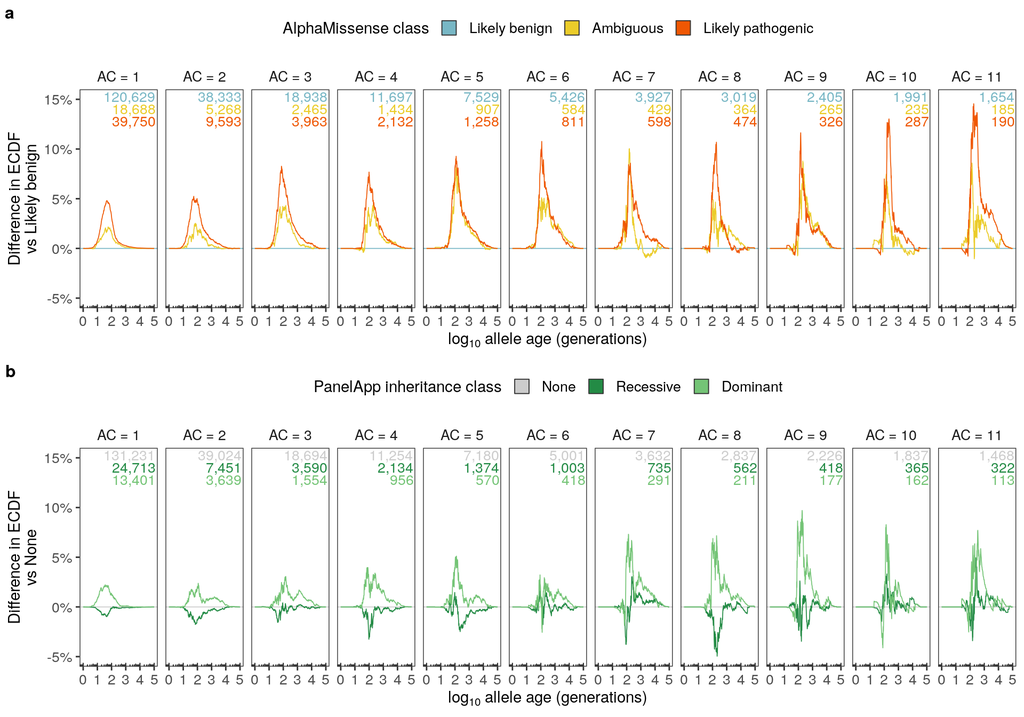

```r
comb_plot <- cowplot::plot_grid(
  p_am_delta_by_ac,
  p_pa_delta_by_ac,
  ncol = 1,
  labels = c("a", "b"),
  label_size = 12
)

comb_plot
```

```r
ggsave("../figures/am_pa-ecdf-by-dac.pdf", comb_plot, width = 10, height = 7)
```

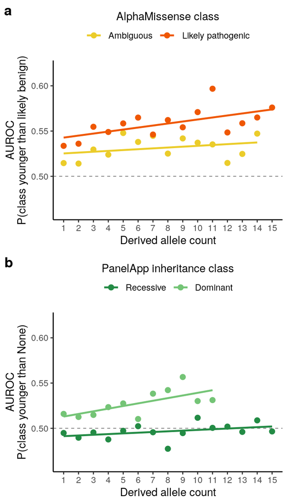

```r
comb_plot <- cowplot::plot_grid(
  p_am_ac_line,
  p_pa_ac_line,
  ncol = 1, labels = c("a", "b")
)
comb_plot
```

```r
ggsave("../figures/am_pa-auroc-by-dac.pdf", comb_plot, width = 4, height = 7)
```

## 4.3 Singleton missense plots across classes

- Log scaled ages by classes (box+whiskers)
- Also Duncan’s sampling QQ plots

### 4.3.1 AlphaMissense

Box and whiskers plot

```r
am_sing_quantiles <- make_age_cat_boxplot(
  ts_df_missense %>%
    filter(AC_ts == 1),
  cat_col   = AM_pred,
  categories = c("Likely benign", "Ambiguous", "Likely pathogenic"),
  colors     = c("#78B7C5", "#EBCC2A", "#EF5703"),
  x_var      = mean_time,
  title      = "Singletons (missense)"
)
```

Duncan’s QQ plot with 95% CIs

```r
am_df = ts_df_missense %>%
  filter(AC_ts == 1) %>%
  dplyr::select(
    shape_time, scale_time, AM_pred
  )

am_qq_data_singletons <- qq_plot_data_from_df(
  df = am_df,
  variable = "AM_pred",
  null_category = "Likely benign",
  num_bootstraps=as.integer(10),
  conf_percent = 95,
  num_points = as.integer(1000)
)

am_qq_plot <- make_age_qq_plot(
  am_qq_data_singletons,
  cat_col    = category,
  categories = c("Likely benign", "Ambiguous", "Likely pathogenic"),
  colors     = c("#78B7C5", "#EBCC2A", "#EF5703"),
  x_var      = null_times,
  y_ratio    = ratio,
  y_lower    = lower,
  y_upper    = upper,
  legend_title = "AlphaMissense class",
  control_level = "Likely benign",
)
```

### 4.3.2 PanelApp mode of inhertiance

Singletons box + whiskers by age

```r
moi_sing_quantiles <- make_age_cat_boxplot(
  ts_df_missense %>%
    filter(AC_ts == 1 & panel_app_moi %in% c("Unknown", "BIALLELIC", "MONOALLELIC")),
  cat_col   = panel_app_moi,
  categories = c("Unknown", "BIALLELIC", "MONOALLELIC"),
  colors     = c("#74c476", "#238b45", "grey80"),
  x_var      = mean_time,
  title      = "Singletons (missense)"
)
```

Singeltons quantiles by age - Category = Unknown (no inhertiance pattern)

```r
moi_df = ts_df_missense %>%
  filter(AC_ts == 1) %>%
  dplyr::select(
    shape_time, scale_time, panel_app_moi
  ) %>%
  drop_na(panel_app_moi) %>%
  filter(panel_app_moi %in% c("Unknown", "BIALLELIC", "MONOALLELIC")) %>%
  mutate(
    ## Rename the categories.
    panel_app_moi = case_when(
      panel_app_moi == "BIALLELIC" ~ "Recessive inheritance",
      panel_app_moi == "MONOALLELIC" ~ "Dominant inheritance",
      TRUE ~ "None"
    )
  )

moi_qq_data_singletons <- qq_plot_data_from_df(
  df = moi_df,
  variable = "panel_app_moi",
  null_category = "None",
  conf_percent = as.integer(95),
  num_bootstraps= as.integer(10),
  num_points = as.integer(1000)
)

moi_qq_plot <- make_age_qq_plot(
  moi_qq_data_singletons,
  cat_col    = category,
  categories = c("None", "Recessive inheritance", "Dominant inheritance"),
  colors     = rev(c("#74c476", "#238b45", "grey80")),
  x_var      = null_times,
  y_ratio    = ratio,
  y_lower    = lower,
  y_upper    = upper,
  legend_title = "PanelApp inheritance class",
  control_level = "None",
)
```

### 4.3.3 PrimateAI-3D

Box and whiskers plot

```r
pai3d_sing_quantiles <- make_age_cat_boxplot(
  ts_df_missense %>%
    drop_na(PAI3D_pred) %>%
    filter(AC_ts == 1),
  cat_col   = PAI3D_pred,
  categories = c("Likely benign", "Ambiguous", "Likely pathogenic"),
  colors     = c("#78B7C5", "#EBCC2A", "#EF5703"),
  x_var      = mean_time,
  title      = "Singletons (missense)"
)
```

Duncan’s QQ plot with 95% CIs

```r
pai3d_df = ts_df_missense %>%
  drop_na(PAI3D_pred)%>%
  filter(AC_ts == 1) %>%
  dplyr::select(
    shape_time, scale_time, PAI3D_pred
  )

pai3d_qq_data_singletons <- qq_plot_data_from_df(
  df = pai3d_df,
  variable = "PAI3D_pred",
  null_category = "Likely benign",
  num_bootstraps=as.integer(10),
  conf_percent = 95,
  num_points = as.integer(1000)
)

pai3d_qq_plot <- make_age_qq_plot(
  pai3d_qq_data_singletons,
  cat_col    = category,
  categories = c("Likely benign", "Ambiguous", "Likely pathogenic"),
  colors     = c("#78B7C5", "#EBCC2A", "#EF5703"),
  x_var      = null_times,
  y_ratio    = ratio,
  y_lower    = lower,
  y_upper    = upper,
  legend_title = "PrimateAI-3D class",
  control_level = "Likely benign",
)
```

## 4.4 Logistic regression of allele age Z-score bins vs probability of class membership

We can test the relationship between mutation age and different classes across the ur spectrum by looking at Z-score bins. - AlphaMissense categories (ur) - PrimateAI-3D categories (ur) - PanelApp mode of inheritance categories (ur)

### 4.4.1 AlphaMissense classes vs Frequency controlled allele age Z-scores bins

Make a plot of numbers of mutations per class

```r
am_n_plot <- cat_n_plot(
  ts_df_missense,
  cat_col      = AM_pred,
  categories   = c("Likely pathogenic", "Ambiguous", "Likely benign"),
  colors       = c("#EF5703", "#EBCC2A", "#78B7C5"),
  filter_ac_ts = TRUE,
  AF_thresh    = 0.001,
  max_ac_fun   = max_ac_count,
  require_non_na = AM_score,
  x_divisor    = 1000,
  x_label      = "Missense variants (thousands)",
  title        = "GEL DAF < 0.1% (missense)",
  legend_title = "AlphaMissense class",
  show_legend  = FALSE
)
```

Run the logistic regression loop

```r
am_logistic_test_z <-
outlier_logistic_loop_wrapper(
  df = ts_df_missense,
  outcome_col = "AM_pred",
  outcome_vec = c("Likely benign", "Ambiguous", "Likely pathogenic"),
  outlier_thresh_vec = c(-Inf, -2, -1, 0, 1, 2, 3, 4, Inf), ## trim lower cateogories.
  outlier_col = "time_z",
  group_vals = c(1:max_ac_count(ts_lf_merge, AF_thresh = 0.001)),
  group_col = "AC_ts",
  direction = "between",
  correct_groups = FALSE,
  group_as_factor = FALSE
)
```

```
## Outlier column: time_z
```

```r
am_logistic_test_z %<>%
mutate(outlier_score = gsub(" - ", " to ", outlier_score),
       outlier_score = case_when(
        outlier_score == "-Inf to -2" ~ "< -2",
        outlier_score == "4 to Inf" ~ "> 4",
        TRUE ~ outlier_score
       ))
```

```r
am_supp_table <- create_outlier_logistic_supp_table(
  test_results = am_logistic_test_z,
  source_df = ts_df_missense,
  csv_file = "data/alphamissense_age_z_logistic.csv",

  outcome_col = "AM_pred",
  outcome_vec = c(
    "Likely benign",
    "Ambiguous",
    "Likely pathogenic"
  ),

  outlier_col = "time_z",
  outlier_thresh_vec = c(-Inf, -2, -1, 0, 1, 2, 3, 4, Inf),

  group_col = "AC_ts",
  group_vals = 1:max_ac_count(ts_lf_merge, AF_thresh = 0.001),

  direction = "between",

  outcome_label = "AlphaMissense class",
  outlier_label = "Ultra-rare (DAF < 0.1%) missense mutation frequency-controlled age Z-score"
)
```

```
##
##
## Table: Logistic regression associations between Ultra-rare (DAF < 0.1%) missense mutation frequency-controlled age Z-score and AlphaMissense class. Odds ratios compare observations within each tested Z-score bin with all observations outside that bin. P values are Wald-test P values.
##
## |Ultra-rare (DAF < 0.1%) missense mutation frequency-controlled age Z-score |AlphaMissense class | N total| N in Z-score bin| N class in Z-score bin| N other in Z-score bin| N outside Z-score bin| N class outside Z-score bin| N other outside Z-score bin|     Beta|      SE| Odds ratio|      95% CI…
## |:--------------------------------------------------------------------------|:-------------------|-------:|----------------:|----------------------:|----------------------:|---------------------:|---------------------------:|---------------------------:|--------:|-------:|----------:|-----------:…
## |< -2                                                                       |Likely benign       |  326121|             3692|                   2314|                   1378|                322429|                      230032|                       92397|   -0.394|  0.0342|      0.675| 0.631-0.721…
## |< -2                                                                       |Ambiguous           |  326121|             3692|                    432|                   3260|                322429|                       31941|                      290488|    0.187|  0.0515|       1.21|   1.09-1.33…
## |< -2                                                                       |Likely pathogenic   |  326121|             3692|                    946|                   2746|                322429|                       60456|                      261973|    0.401|   0.038|       1.49|   1.39-1.61…
## |-2 to -1                                                                   |Likely benign       |  326121|            35501|                  23525|                  11976|                290620|                      208821|                       81799|   -0.262|   0.012|      0.769| 0.752-0.788…
## |-2 to -1                                                                   |Ambiguous           |  326121|            35501|                   3688|                  31813|                290620|                       28685|                      261935|   0.0569|  0.0185|       1.06|    1.02-1.1…
## |-2 to -1                                                                   |Likely pathogenic   |  326121|            35501|                   8288|                  27213|                290620|                       53114|                      237506|    0.309|  0.0134|       1.36|    1.33-1.4…
## |-1 to 0                                                                    |Likely benign       |  326121|           141969|                 101244|                  40725|                184152|                      131102|                       53050|  0.00595|  0.0078|       1.01|  0.991-1.02…
## |-1 to 0                                                                    |Ambiguous           |  326121|           141969|                  14171|                 127798|                184152|                       18202|                      165950|   0.0109|  0.0118|       1.01|  0.988-1.03…
## |-1 to 0                                                                    |Likely pathogenic   |  326121|           141969|                  26554|                 115415|                184152|                       34848|                      149304|  -0.0144| 0.00904|      0.986|     0.968-1…
## |0 to 1                                                                     |Likely benign       |  326121|           109011|                  78369|                  30642|                217110|                      153977|                       63133|   0.0475| 0.00823|       1.05|   1.03-1.07…
## |0 to 1                                                                     |Ambiguous           |  326121|           109011|                  10773|                  98238|                217110|                       21600|                      195510| -0.00743|  0.0124|      0.993|  0.969-1.02…
## |0 to 1                                                                     |Likely pathogenic   |  326121|           109011|                  19869|                  89142|                217110|                       41533|                      175577|  -0.0595| 0.00956|      0.942|  0.925-0.96…
## |1 to 2                                                                     |Likely benign       |  326121|            25723|                  18885|                   6838|                300398|                      213461|                       86937|    0.118|  0.0147|       1.12|   1.09-1.16…
## |1 to 2                                                                     |Ambiguous           |  326121|            25723|                   2446|                  23277|                300398|                       29927|                      270471|  -0.0516|  0.0221|       0.95| 0.909-0.992…
```

[output cut: 10 more lines]

Plot…

```r
am_zcat_plot <- am_logistic_test_z %>%
enrichment_depletion_plot(
  group_col = "AM_pred",
  group_vals = c("Likely benign", "Ambiguous", "Likely pathogenic"),
  outlier_scores = unique(.$outlier_score),
  colours_vec = c("#78B7C5", "#EBCC2A", "#EF5703"),
)
```

### 4.4.2 PanelApp inheritance classes vs Frequency controlled allele age Z-scores bins

We expect that monoallelic vs biallelic inheritance would influence purifying selection. Is there a difference in age distributions of missense variants across clinically relevant recessive/dominant genes in terms of mutation ages, even when controlling for frequency?

We can look at PanelApp (https://panelapp.genomicsengland.co.uk/) for this. - gel-ts_df.Rmd annotated each variant with the mode of inheritance of any PanelApp gene they overlapped with.

Make a plot of numbers of missense mutations per class

```r
moi_n_plot <- cat_n_plot(
  ts_df_missense,
  cat_col      = panel_app_moi,
  categories   = c("BIALLELIC", "MONOALLELIC", "Unknown"),
  colors       = c("#238b45", "#74c476", "grey80"),
  filter_ac_ts = TRUE,
  AF_thresh    = 0.001,
  max_ac_fun   = max_ac_count,
  require_non_na = panel_app_moi,
  x_divisor    = 1000,
  x_label      = "Missense variants (thousands)",
  title        = "GEL DAF < 0.1% (missense)",
  legend_title = "PanelApp inheritance class",
  show_legend  = FALSE
)
```

Run the logistic regression loop

```r
moi_logistic_test_z <-
outlier_logistic_loop_wrapper(
   ts_df_missense %>%
    filter(panel_app_moi %in% c("BIALLELIC", "Unknown", "MONOALLELIC")),
  outcome_col = "panel_app_moi",
  outcome_vec = c("BIALLELIC", "Unknown", "MONOALLELIC"),
  outlier_thresh_vec = c(-Inf, -2, -1, 0, 1, 2, 3, 4, Inf),
  outlier_col = "time_z",
  group_vals = c(1:max_ac_count(ts_lf_merge, AF_thresh = 0.001)),
  group_col = "AC_ts",
  direction = "between",
  correct_groups = FALSE,
  group_as_factor = FALSE
)
```

```
## Outlier column: time_z
```

```r
moi_logistic_test_z %<>%
mutate(outlier_score = gsub(" - ", " to ", outlier_score),
       outlier_score = case_when(
        outlier_score == "-Inf to -2" ~ "< -2",
        outlier_score == "4 to Inf" ~ "> 4",
        TRUE ~ outlier_score
       ))
```

```r
moi_supp_table <- create_outlier_logistic_supp_table(
  test_results = moi_logistic_test_z,

  source_df = ts_df_missense %>%
    filter(
      panel_app_moi %in%
        c("BIALLELIC", "Unknown", "MONOALLELIC")
    ),

  csv_file = "data/moi_age_z_logistic.csv",

  outcome_col = "panel_app_moi",
  outcome_vec = c(
    "BIALLELIC",
    "Unknown",
    "MONOALLELIC"
  ),

  outlier_col = "time_z",
  outlier_thresh_vec = c(-Inf, -2, -1, 0, 1, 2, 3, 4, Inf),

  group_col = "AC_ts",
  group_vals = 1:max_ac_count(ts_lf_merge, AF_thresh = 0.001),

  direction = "between",

  outlier_label = "Ultra-rare (DAF < 0.1%) missense mutation frequency-controlled age Z-score",
  outcome_label = "Mode of inheritance class"
)
```

```
##
##
## Table: Logistic regression associations between Ultra-rare (DAF < 0.1%) missense mutation frequency-controlled age Z-score and Mode of inheritance class. Odds ratios compare observations within each tested Z-score bin with all observations outside that bin. P values are Wald-test P values.
##
## |Ultra-rare (DAF < 0.1%) missense mutation frequency-controlled age Z-score |Mode of inheritance class | N total| N in Z-score bin| N class in Z-score bin| N other in Z-score bin| N outside Z-score bin| N class outside Z-score bin| N other outside Z-score bin|     Beta|      SE| Odds ratio|      …
## |:--------------------------------------------------------------------------|:-------------------------|-------:|----------------:|----------------------:|----------------------:|---------------------:|---------------------------:|---------------------------:|--------:|-------:|----------:|------…
## |< -2                                                                       |BIALLELIC                 |  307682|             3513|                    455|                   3058|                304169|                       45047|                      259122|   -0.156|  0.0505|      0.856| 0.775…
## |< -2                                                                       |Unknown                   |  307682|             3513|                   2705|                    808|                304169|                      236933|                       67236|  -0.0513|  0.0403|       0.95|  0.87…
## |< -2                                                                       |MONOALLELIC               |  307682|             3513|                    353|                   3160|                304169|                       22189|                      281980|     0.35|  0.0566|       1.42|   1.2…
## |-2 to -1                                                                   |BIALLELIC                 |  307682|            33693|                   4706|                  28987|                273989|                       40796|                      233193|  -0.0747|  0.0166|      0.928| 0.898…
## |-2 to -1                                                                   |Unknown                   |  307682|            33693|                  26213|                   7480|                273989|                      213425|                       60564| -0.00556|  0.0139|      0.994|  0.96…
## |-2 to -1                                                                   |MONOALLELIC               |  307682|            33693|                   2774|                  30919|                273989|                       19768|                      254221|    0.143|  0.0212|       1.15|    1.…
## |-1 to 0                                                                    |BIALLELIC                 |  307682|           134005|                  19819|                 114186|                173677|                       25683|                      147994| 0.000155|  0.0102|          1|   0.9…
## |-1 to 0                                                                    |Unknown                   |  307682|           134005|                 104402|                  29603|                173677|                      135236|                       38441|  0.00248| 0.00876|          1|  0.98…
## |-1 to 0                                                                    |MONOALLELIC               |  307682|           134005|                   9784|                 124221|                173677|                       12758|                      160919| -0.00657|   0.014|      0.993|  0.96…
## |0 to 1                                                                     |BIALLELIC                 |  307682|           102626|                  15444|                  87182|                205056|                       30058|                      174998|   0.0309|  0.0107|       1.03|   1.0…
## |0 to 1                                                                     |Unknown                   |  307682|           102626|                  79800|                  22826|                205056|                      159838|                       45218|   -0.011|  0.0092|      0.989|  0.97…
## |0 to 1                                                                     |MONOALLELIC               |  307682|           102626|                   7382|                  95244|                205056|                       15160|                      189896|  -0.0296|  0.0147|      0.971| 0.943…
## |1 to 2                                                                     |BIALLELIC                 |  307682|            24156|                   3556|                  20600|                283526|                       41946|                      241580| -0.00584|  0.0189|      0.994|  0.95…
## |1 to 2                                                                     |Unknown                   |  307682|            24156|                  18902|                   5254|                283526|                      220736|                       62790|   0.0231|  0.0162|       1.02|  0.99…
```

[output cut: 10 more lines]

Plot…

```r
moi_zcat_plot <- moi_logistic_test_z %>%
enrichment_depletion_plot(
  group_col = "panel_app_moi",
  group_vals = c("BIALLELIC", "MONOALLELIC", "Unknown"),
  outlier_scores = unique(.$outlier_score),
  colours_vec = c("#238b45", "#74c476", "grey80"),
)
```

### 4.4.3 PrimateAI-3D

Make a plot of numbers of mutations per class

```r
pai3d_n_plot <- cat_n_plot(
  ts_df_missense %>%
    drop_na(PAI3D_pred),
  cat_col      = PAI3D_pred,
  categories   = c("Likely pathogenic", "Ambiguous", "Likely benign"),
  colors       = c("#EF5703", "#EBCC2A", "#78B7C5"),
  filter_ac_ts = TRUE,
  AF_thresh    = 0.001,
  max_ac_fun   = max_ac_count,
  require_non_na = PAI3D_score,
  x_divisor    = 1000,
  x_label      = "Missense variants (thousands)",
  title        = "GEL DAF < 0.1% (missense)",
  legend_title = "PrimateAI-3D class",
  show_legend  = FALSE
)
```

Run the logistic regression loop

```r
pai3d_logistic_test_z <-
outlier_logistic_loop_wrapper(
  df = ts_df_missense %>%
    drop_na(PAI3D_pred),
  outcome_col = "PAI3D_pred",
  outcome_vec = c("Likely benign", "Ambiguous", "Likely pathogenic"),
  outlier_thresh_vec = c(-Inf, -2, -1, 0, 1, 2, 3, 4, Inf), ## trim lower cateogories.
  outlier_col = "time_z",
  group_vals = c(1:max_ac_count(ts_lf_merge, AF_thresh = 0.001)),
  group_col = "AC_ts",
  direction = "between",
  correct_groups = FALSE,
  group_as_factor = FALSE
)
```

```
## Outlier column: time_z
```

```r
pai3d_logistic_test_z %<>%
mutate(outlier_score = gsub(" - ", " to ", outlier_score),
       outlier_score = case_when(
        outlier_score == "-Inf to -2" ~ "< -2",
        outlier_score == "4 to Inf" ~ "> 4",
        TRUE ~ outlier_score
       ))
```

```r
pai3d_supp_table <- create_outlier_logistic_supp_table(
  test_results = pai3d_logistic_test_z,

  source_df = ts_df_missense %>%
    drop_na(PAI3D_pred),

  csv_file = "data/pai3d_age_z_logistic.csv",

  outcome_col = "PAI3D_pred",
  outcome_vec = c(
    "Likely benign",
    "Ambiguous",
    "Likely pathogenic"
  ),

  outlier_col = "time_z",
  outlier_thresh_vec = c(-Inf, -2, -1, 0, 1, 2, 3, 4, Inf),

  group_col = "AC_ts",
  group_vals = 1:max_ac_count(ts_lf_merge, AF_thresh = 0.001),

  direction = "between",

  outlier_label = "Ultra-rare (DAF < 0.1%) missense mutation frequency-controlled age Z-score",
  outcome_label = "PrimateAI-3D class"
)
```

```
##
##
## Table: Logistic regression associations between Ultra-rare (DAF < 0.1%) missense mutation frequency-controlled age Z-score and PrimateAI-3D class. Odds ratios compare observations within each tested Z-score bin with all observations outside that bin. P values are Wald-test P values.
##
## |Ultra-rare (DAF < 0.1%) missense mutation frequency-controlled age Z-score |PrimateAI-3D class | N total| N in Z-score bin| N class in Z-score bin| N other in Z-score bin| N outside Z-score bin| N class outside Z-score bin| N other outside Z-score bin|    Beta|      SE| Odds ratio|      95% CI| …
## |:--------------------------------------------------------------------------|:------------------|-------:|----------------:|----------------------:|----------------------:|---------------------:|---------------------------:|---------------------------:|-------:|-------:|----------:|-----------:|-…
## |< -2                                                                       |Likely benign      |  310486|             3515|                   1882|                   1633|                306971|                      184584|                      122387|  -0.269|   0.034|      0.764| 0.715-0.817| …
## |< -2                                                                       |Ambiguous          |  310486|             3515|                   1040|                   2475|                306971|                       85601|                      221370|  0.0831|  0.0372|       1.09|   1.01-1.17| …
## |< -2                                                                       |Likely pathogenic  |  310486|             3515|                    593|                   2922|                306971|                       36786|                      270185|   0.399|  0.0454|       1.49|   1.36-1.63| …
## |-2 to -1                                                                   |Likely benign      |  310486|            33696|                  18770|                  14926|                276790|                      167696|                      109094|  -0.201|  0.0116|      0.818|   0.8-0.837| …
## |-2 to -1                                                                   |Ambiguous          |  310486|            33696|                   9888|                  23808|                276790|                       76753|                      200037|  0.0792|  0.0127|       1.08|   1.06-1.11| …
## |-2 to -1                                                                   |Likely pathogenic  |  310486|            33696|                   5038|                  28658|                276790|                       32341|                      244449|   0.284|  0.0164|       1.33|   1.29-1.37| …
## |-1 to 0                                                                    |Likely benign      |  310486|           134975|                  81116|                  53859|                175511|                      105350|                       70161| 0.00302| 0.00739|          1|  0.989-1.02| …
## |-1 to 0                                                                    |Ambiguous          |  310486|           134975|                  37743|                  97232|                175511|                       48898|                      126613|  0.0051| 0.00807|       1.01|  0.989-1.02| …
## |-1 to 0                                                                    |Likely pathogenic  |  310486|           134975|                  16116|                 118859|                175511|                       21263|                      154248| -0.0165|  0.0111|      0.984|  0.962-1.01| …
## |0 to 1                                                                     |Likely benign      |  310486|           104009|                  63145|                  40864|                206477|                      123321|                       83156|  0.0411| 0.00777|       1.04|   1.03-1.06| …
## |0 to 1                                                                     |Ambiguous          |  310486|           104009|                  28758|                  75251|                206477|                       57883|                      148594| -0.0191| 0.00849|      0.981| 0.965-0.998| …
## |0 to 1                                                                     |Likely pathogenic  |  310486|           104009|                  12106|                  91903|                206477|                       25273|                      181204| -0.0571|  0.0118|      0.944| 0.923-0.967| …
## |1 to 2                                                                     |Likely benign      |  310486|            24606|                  15270|                   9336|                285880|                      171196|                      114684|  0.0914|  0.0137|        1.1|   1.07-1.13| …
## |1 to 2                                                                     |Ambiguous          |  310486|            24606|                   6687|                  17919|                285880|                       79954|                      205926| -0.0396|  0.0149|      0.961|  0.933-0.99| …
```

[output cut: 10 more lines]

Plot…

```r
pai3d_zcat_plot <- pai3d_logistic_test_z %>%
enrichment_depletion_plot(
  group_col = "PAI3D_pred",
  group_vals = c("Likely benign", "Ambiguous", "Likely pathogenic"),
  outlier_scores = unique(.$outlier_score),
  colours_vec = c("#78B7C5", "#EBCC2A", "#EF5703"),
)
```

## 4.5 Combined main plot

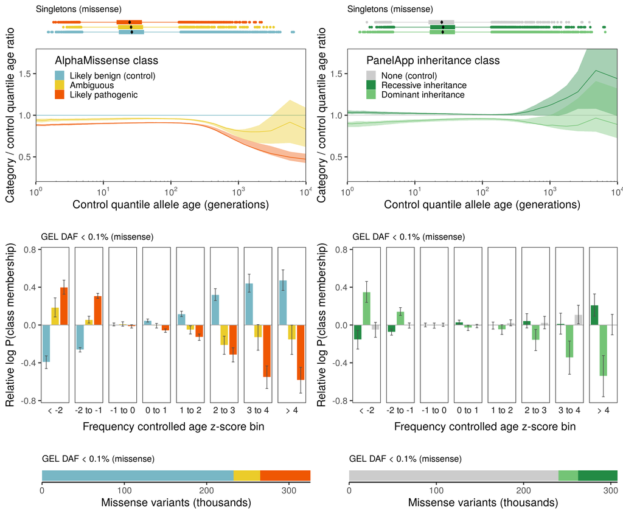

```r
missense_cat_plot <- ggarrange(
  ggarrange(
    ggarrange(am_sing_quantiles, am_qq_plot, align = "v", ncol = 1, heights = c(0.25, 1)),
    ggarrange(moi_sing_quantiles, moi_qq_plot, ncol = 1, align = "v", heights = c(0.25, 1)),
    nrow = 1
  ),
  NULL,
  ggarrange(am_zcat_plot, moi_zcat_plot, nrow = 1),
  NULL,
  ggarrange(NULL, am_n_plot, NULL, moi_n_plot, nrow = 1, widths = c(0.07, 1, 0.04, 1)),
  ncol = 1,
  heights = c(0.925, 0.05, 0.9, 0.05, 0.275)
)
missense_cat_plot
```

Save to PDF for paper

```r
ggsave(paste0(paths$plots_dir, "tmp_alpha_missense_panelapp_freq_plot_toedit.pdf"), missense_cat_plot, width = 15.75, height = 13)
```

PrimateAI-3D supplemental plot

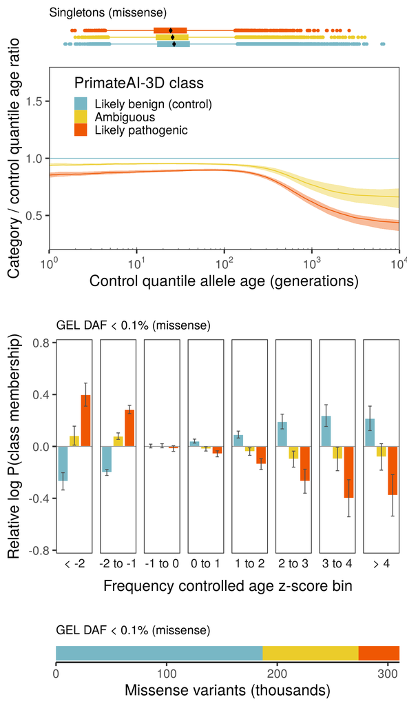

```r
pai3d_supp_plot <- ggarrange(
  ggarrange(pai3d_sing_quantiles, pai3d_qq_plot, align = "v", ncol = 1, heights = c(0.25, 1)),
  NULL,
  pai3d_zcat_plot,
  NULL,
  ggarrange(NULL, pai3d_n_plot, nrow = 1, widths = c(0.07, 1)),
  ncol = 1,
  heights = c(0.925, 0.05, 0.9, 0.05, 0.275)
)
pai3d_supp_plot
```

Save to PDF

```r
ggsave(paste0(paths$plots_dir, "primateai_3d_age_freq_plot.pdf"), pai3d_supp_plot, width = 8, height = 13)
```

Ill manually annotate with some stuff too.

## 4.6 Constraint Z-score plot

gnomADv3.1 released Z-scores showing mutational constraint across chromosomes We can take a look at if there is any enrichment/depletion of allele frequency / allele age outliers (Z-scores) within constraint Z-score bins.

Z-scoring just across chromosome 17

```r
ts_df_chr17 <- ts_lf_merge %>%
filter(chromosome == "chr17") %>%
dplyr::select(-time_z) %>%
z_normalise(
      group_col = "AC_ts",
      score_col = "mean_time",
      z_col = "time_z",
      log10 = TRUE
) %>%
as_tibble()
```

```r
## takes a while, checkpoint
checkpoint_gnocchi_regress <- paste0(
  paths$output_dir,
  "checkpoints/all-chr17-gnocchi_z-regression.tsv.gz"
)

cat("Gnocchi checkpoint:", checkpoint_gnocchi_regress, "\n")
```

```
## Gnocchi checkpoint: /pgen_int_work/BRS/dd/sam/projects/gel-dating-paper/output_data/checkpoints/all-chr17-gnocchi_z-regression.tsv.gz
```

```r
if (file.exists(checkpoint_gnocchi_regress)) {

  cat("Loading existing Gnocchi regression checkpoint\n")

  gnocchi_logistic_test_between_z <- data.table::fread(
    checkpoint_gnocchi_regress
  )

} else {

  cat("Checkpoint not found; running Gnocchi regressions\n")

  gnocchi_logistic_test_between_z <-
    outlier_logistic_loop_wrapper(
      df = ts_df_chr17,
      outcome_col = "gnocchi_z",
      outcome_vec = c(
        "<n4", "n3-n4", "n2-n3", "n1-n2",
        "0-n1", "0-1", "1-2", "2-3", "3-4", ">=4"
      ),
      outlier_thresh_vec = c(-Inf, 0, 1, 2, 3, 4, Inf),
      outlier_col = "time_z",
      group_vals = 1:max_ac_count(
        ts_lf_merge,
        AF_thresh = 0.001
      ),
      group_col = "AC_ts",
      direction = "between",
      correct_groups = FALSE,
      group_as_factor = FALSE
    )

  data.table::fwrite(
    gnocchi_logistic_test_between_z,
    checkpoint_gnocchi_regress,
    sep = "\t"
  )
}
```

```
## Loading existing Gnocchi regression checkpoint
```

```r
gnocchi_logistic_test_between_z %<>%
  mutate(
    outlier_score = gsub(
      " - ",
      " to ",
      outlier_score
    ),
    outlier_score = case_when(
      outlier_score == "-Inf to 0" ~ "< 0",
      outlier_score == "4 to Inf" ~ "> 4",
      TRUE ~ outlier_score
    )
  )
```

```r
cat("Gnocchi results dimensions:",
    nrow(gnocchi_logistic_test_between_z),
    "x",
    ncol(gnocchi_logistic_test_between_z),
    "\n")
```

```
## Gnocchi results dimensions: 60 x 13
```

```r
print(names(gnocchi_logistic_test_between_z))
```

```
##  [1] "estimate"       "std.error"      "statistic"      "p.value"
##  [5] "conf.high"      "conf.low"       "p.adjust"       "gnocchi_z"
##  [9] "outlier_score"  "outlier_method" "group"          "outcome"
## [13] "direction"
```

```r
gnocchi_supp_table <- create_outlier_logistic_supp_table(
  test_results = gnocchi_logistic_test_between_z,

  source_df = ts_df_chr17,

  csv_file = "data/gnocchi_age_z_logistic.csv",

  outcome_col = "gnocchi_z",

  outcome_vec = c(
    "<n4",
    "n3-n4",
    "n2-n3",
    "n1-n2",
    "0-n1",
    "0-1",
    "1-2",
    "2-3",
    "3-4",
    ">=4"
  ),

  outlier_col = "time_z",
  outlier_thresh_vec = c(-Inf, 0, 1, 2, 3, 4, Inf),

  group_col = "AC_ts",
  group_vals = 1:max_ac_count(ts_lf_merge, AF_thresh = 0.001),

  direction = "between",

  outlier_label = "Ultra-rare (DAF < 0.1%) mutation frequency-controlled age Z-score",
  outcome_label = "Gnocchi constraint category"
)
```

```
##
##
## Table: Logistic regression associations between Ultra-rare (DAF < 0.1%) mutation frequency-controlled age Z-score and Gnocchi constraint category. Odds ratios compare observations within each tested Z-score bin with all observations outside that bin. P values are Wald-test P values.
##
## |Ultra-rare (DAF < 0.1%) mutation frequency-controlled age Z-score |Gnocchi constraint category | N total| N in Z-score bin| N class in Z-score bin| N other in Z-score bin| N outside Z-score bin| N class outside Z-score bin| N other outside Z-score bin|     Beta|      SE| Odds ratio|      95% CI|…
## |:-----------------------------------------------------------------|:---------------------------|-------:|----------------:|----------------------:|----------------------:|---------------------:|---------------------------:|---------------------------:|--------:|-------:|----------:|-----------:|…
## |< 0                                                               |<n4                         | 5142796|          2863068|                  22878|                2840190|               2279728|                       17457|                     2262271|   0.0429|  0.0101|       1.04|   1.02-1.06|…
## |< 0                                                               |n3-n4                       | 5142796|          2863068|                  23356|                2839712|               2279728|                       19088|                     2260640|  -0.0263|  0.0098|      0.974| 0.956-0.993|…
## |< 0                                                               |n2-n3                       | 5142796|          2863068|                  75838|                2787230|               2279728|                       62603|                     2217125|  -0.0371| 0.00547|      0.964| 0.953-0.974|…
## |< 0                                                               |n1-n2                       | 5142796|          2863068|                 202936|                2660132|               2279728|                      163203|                     2116525|  -0.0107| 0.00345|      0.989| 0.983-0.996|…
## |< 0                                                               |0-n1                        | 5142796|          2863068|                 426716|                2436352|               2279728|                      337210|                     1942518|   0.0089|  0.0025|       1.01|      1-1.01|…
## |< 0                                                               |0-1                         | 5142796|          2863068|                 652738|                2210330|               2279728|                      512075|                     1767653|   0.0192| 0.00212|       1.02|   1.02-1.02|…
## |< 0                                                               |1-2                         | 5142796|          2863068|                 675527|                2187541|               2279728|                      528122|                     1751606|   0.0239|  0.0021|       1.02|   1.02-1.03|…
## |< 0                                                               |2-3                         | 5142796|          2863068|                 445490|                2417578|               2279728|                      358252|                     1921476|  -0.0117| 0.00244|      0.988| 0.984-0.993|…
## |< 0                                                               |3-4                         | 5142796|          2863068|                 206820|                2656248|               2279728|                      172014|                     2107714|   -0.047| 0.00339|      0.954|  0.948-0.96|…
## |< 0                                                               |>=4                         | 5142796|          2863068|                 130769|                2732299|               2279728|                      109704|                     2170024|  -0.0548| 0.00419|      0.947| 0.939-0.955|…
## |0 to 1                                                            |<n4                         | 5142796|          1693583|                  12623|                1680960|               3449213|                       27712|                     3421501|  -0.0756|  0.0108|      0.927| 0.908-0.947|…
```

[output cut: 49 more lines]

```r
order_constraint <- c("<n4", "n3-n4", "n2-n3", "n1-n2", "0-n1", "0-1", "1-2", "2-3", "3-4", ">=4")
gnocchi_z_plot <- gnocchi_logistic_test_between_z %>%
enrichment_depletion_plot(
  group_col = "gnocchi_z",
  outlier_scores = unique(gnocchi_logistic_test_between_z$outlier_score),
  group_vals = order_constraint
) +
scale_fill_viridis(option = "A", discrete = TRUE) +
scale_color_viridis(option = "A", discrete = TRUE) +
labs(
  x = "Frequency-controlled age z-score bin",
  y = "Relative P(class membership)"
) +
coord_cartesian(ylim = c(-0.5, 0.5)) +
ggtitle("GEL DAF < 0.1%") +
theme(
    plot.title = element_text(size = rel(0.8)),  # Match axis text size
    axis.text = element_text(size = rel(0.8))    # Adjust axis text size if needed
  )
```

Constraint Z scores

```r
#### gnocchi constraint
constraint_gnocchi <- fread(
    file.path(paste0(paths$output,"all-chr17-gnocchi_constraint.tsv.gz"))
  ) %>%
  filter(
    !(start > 18276569 & end < 26718757)
  )
```

```r
gnocchi_plot_constraint <- constraint_gnocchi %>%
  mutate(
    ymax = 1, ymin = -1,
    gnocchi_z = factor(gnocchi_z, levels = order_constraint)
  ) %>%
  ggplot() +
  theme_bw(base_size = 20) +
  geom_rect(
    aes(xmin = start/1e6, xmax = end/1e6,
        ymin = ymin, ymax = ymax,
        colour = gnocchi_z, fill = gnocchi_z),
    alpha = 0.75
  ) +
  scale_y_continuous(expand = c(0,0)) +
  scale_x_continuous(expand = c(0,0)) +
  scale_fill_viridis(option = "A", discrete = TRUE) +
  scale_color_viridis(option = "A", discrete = TRUE) +
  labs(
    x = "Position (Mb)\nChromosome 17",
    fill   = "gnocchi constraint class (z-score bin)",
    colour = "gnocchi constraint class (z-score bin)"
  ) +
  guides(
    fill = guide_legend(
      title.position = "top",
      title.hjust    = 0.5,
      nrow           = 1,
      label = FALSE,
      keywidth  = unit(25, "pt"),
      keyheight = unit(25, "pt")
    ),
    colour = "none"
  ) +
  theme(
    legend.position     = "top",
    legend.box          = "horizontal",
    legend.title.align  = 0.5,
    legend.spacing.x     = unit(3, "pt"),
    panel.grid          = element_blank(),
    axis.text.y         = element_blank(),
    axis.title.y        = element_blank(),
    axis.ticks.y        = element_blank()
  ) +
  geom_vline(xintercept = c(18276569, 26718757)/1e6, linewidth = 0.5)
```

[figure not shown]

```r
gnocchi_z_score_fig <- ggarrange(
  ggarrange(NULL, gnocchi_plot_constraint, nrow = 1, widths = c(0.07, 1)),
  NULL,
  gnocchi_z_plot,
  ncol = 1,
  heights = c(0.65, 0.05, 1)
)
gnocchi_z_score_fig
```

Save to PDF for paper

```r
ggsave(paste0(paths$plots_dir, "tmp_gel_constraint_gnocchi_figure_toedit.pdf"), gnocchi_z_score_fig, width = 12, height = 9)
```